# Donor Profile: Netherlands - Ministry of Foreign Affairs

## Transaction Volatility

The Netherlands Ministry of Foreign Affairs maintains a high transaction value averaging $2.7M through only 34.5 transactions yearly, sharply contrasting with top donors averaging 2.9M$ via nearly 592 transactions. This pronounced funding volatility constrains agility and sustained impact in critical emergency response operations, impairing UNHCR’s ability to rapidly scale and maintain resilience programs. With a standard deviation in transaction size exceeding $5.3M, inconsistent disbursement timing introduces risks to program continuity and reduces donor ROI through limited portfolio diversification. Strategic investment in encouraging more frequent, smaller transactions from this donor represents a high-leverage opportunity. Scaling transaction frequency to donor benchmarks can multiply impact by enhancing predictable cash flows and enabling timely, adaptable aid delivery. Accelerating partnership dialogues to reduce funding gaps and volatility should be prioritized as a key strategic action. Executive leadership can leverage these insights to negotiate tailored transaction structures with the Netherlands, unlocking sustained funding flows aligned with donor preferences for accountability and innovation in crisis response. Prompt action to stabilize transaction cadence will serve as an impact multiplier, strengthening both operational risk management and donor confidence.

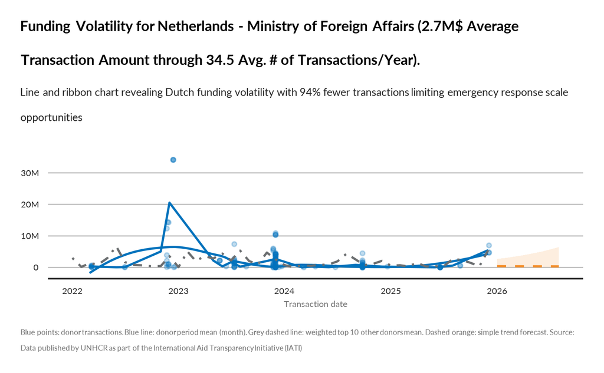

TRUE